# prob1-cp2

## Problema 1 - Checkpoint 2

### Análise Descritiva

Nossa análise será voltada para o exploração e visualização de dados. Os dados utilizados nessa análise são referentes as disciplinas dos cursos da UFCG, por motivos de segurança os nomes dos alunos foram removidos e não tivemos acesso a essa informação, os dados contemplam o período de 2002 a 2014.

Vamos dar uma olhada nos nossos dados:

```r
str(dados)
```

```
## 'data.frame':    920529 obs. of  17 variables:
##  $ Matricula       : chr  "B7350" "B7350" "B7350" "B7350" ...
##  $ Cod_Curso       : int  14102100 14102100 14102100 14102100 14102100 14102100 14102100 14102100 14102100 14102100 ...
##  $ Cod_Disciplina  : int  1411191 1411196 1411255 1411173 1109035 1411190 1411262 1305220 1411169 1411192 ...
##  $ Cod_Evasao      : int  0 0 0 0 0 0 0 0 0 0 ...
##  $ Nome_Curso      : chr  "CIÊNCIA DA COMPUTAÇÃO - D" "CIÊNCIA DA COMPUTAÇÃO - D" "CIÊNCIA DA COMPUTAÇÃO - D" "CIÊNCIA DA COMPUTAÇÃO - D" ...
##  $ Periodo         : num  2004 2005 2005 2003 2002 ...
##  $ Nome_Disciplina : chr  "INTERCONEXÃO DE REDES DE COMPUTADORES" "INTELIGENCIA ARTIFICIAL I" "TECC(LAB DE SISTEMAS OPERACIONAIS)" "LÓGICA MATEMÁTICA" ...
##  $ Creditos        : int  2 4 2 4 4 4 2 2 2 4 ...
##  $ Departamento    : chr  "UNID. ACAD. DE SISTEMAS E COMPUTAÇÃO" "UNID. ACAD. DE SISTEMAS E COMPUTAÇÃO" "UNID. ACAD. DE SISTEMAS E COMPUTAÇÃO" "UNID. ACAD. DE SISTEMAS E COMPUTAÇÃO" ...
##  $ Media_Disciplina: num  8.5 9.3 10 8.7 9.3 8.5 9.2 10 10 8.6 ...
##  $ Situacao        : chr  "Aprovado" "Aprovado" "Aprovado" "Aprovado" ...
##  $ Centro          : int  14 14 14 14 14 14 14 14 14 14 ...
##  $ Campus          : int  1 1 1 1 1 1 1 1 1 1 ...
##  $ Creditos_Curso  : int  208 208 208 208 208 208 208 208 208 208 ...
##  $ Tipo            : chr  "Obrigatória" "Obrigatória" "Optativa" "Obrigatória" ...
##  $ Periodo_Ingresso: num  2002 2002 2002 2002 2002 ...
##  $ Periodo_Relativo: int  6 7 7 4 1 5 8 6 4 7 ...
```

Os dados representam uma visão do banco de dados do controle acadêmico da UFCG. Os campos são praticamente auto-explicativos, com excessão talvez dos seguintes campos que são explicados abaixo:

Cod_Evasao = 0 se o aluno nao evadiu ao fim do primeiro periodo e 1 se ele evadiu.

Credito_Curso = total de créditos necessários para o aluno concluir o curso.

Periodo_Ingresso = periodo que o aluno entrou no curso.

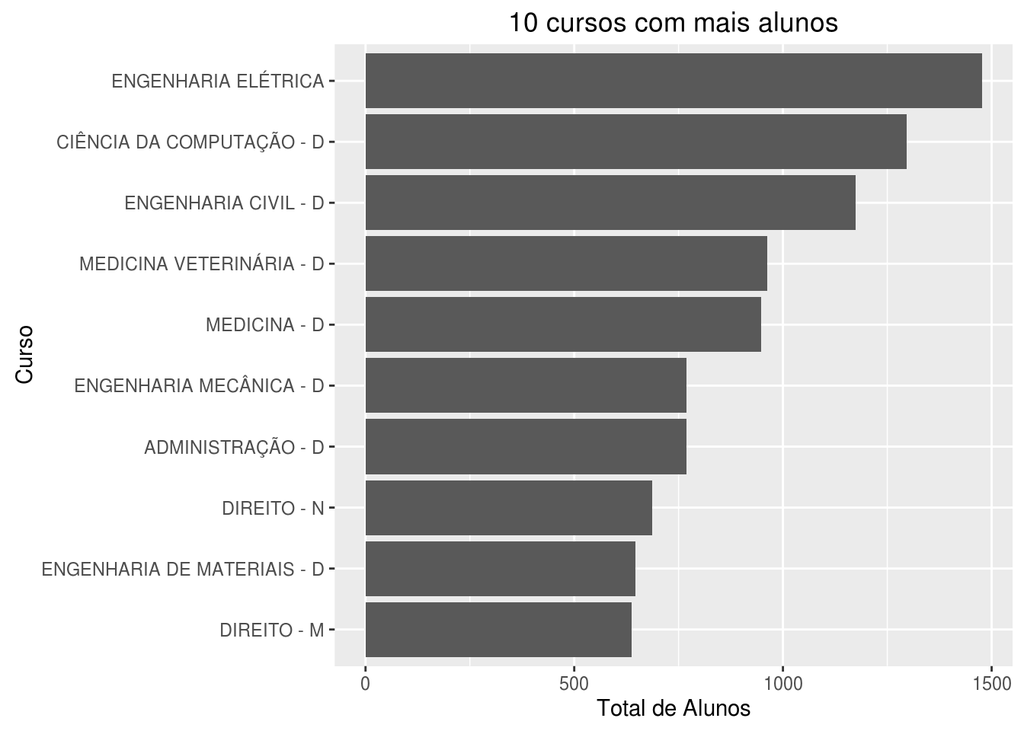

```r
#numero de alunos por curso na UFCG 2002 - 2014
n_alunos_curso <- dados %>%
  select(Matricula, Cod_Curso, Nome_Curso, Departamento, Periodo, Campus) %>%
  distinct(Matricula, Cod_Curso, Nome_Curso, Campus) %>%
  group_by(Nome_Curso, Cod_Curso, Campus) %>%
  summarise(n_alunos = n())

n_alunos_curso <- n_alunos_curso[order(-n_alunos_curso$n_alunos),]

ggplot(data=n_alunos_curso[1:10,], aes(x=reorder(Nome_Curso, n_alunos), y=n_alunos, group=1)) +
  geom_bar(stat="identity") +
  coord_flip() +
  labs(title="10 cursos com mais alunos", x="Curso", y="Total de Alunos")
```

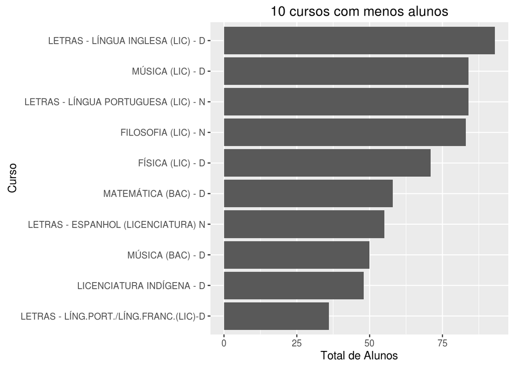

```r
ggplot(data=n_alunos_curso[86:95,], aes(x=reorder(Nome_Curso, n_alunos), y=n_alunos, group=1)) +
  geom_bar(stat="identity") +
  coord_flip() +
  labs(title="10 cursos com menos alunos", x="Curso", y="Total de Alunos")
```

Nos gráficos acima temos uma visão geral da quantidade de alunos que já passaram pelo cursos da UFCG entre 2002 e 2014. Temos um total de 95 cursos espalhados por 9 campus. Escolhemos reduzir o escopo e exbir apenas os 10 cursos com mais alunos e os 10 com menos, devido a quatidade de cursos ser alta e atrapalhar a visualização.

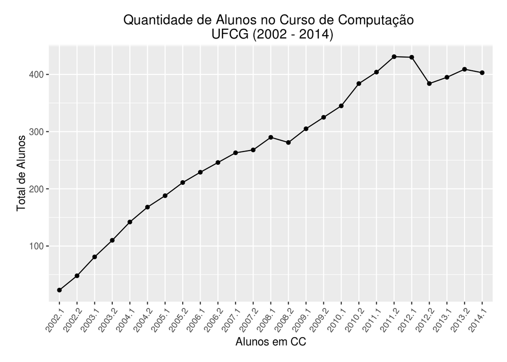

```r
#Numero de alunos no curso de computação 2002 - 2014
n_alunos_curso_CC <- dados %>%
  filter(Cod_Curso == 14102100) %>%
  select(Matricula, Cod_Curso, Nome_Curso, Departamento, Periodo, Campus) %>%
  distinct(Matricula, Cod_Curso, Nome_Curso, Campus, Periodo) %>%
  group_by(Nome_Curso, Cod_Curso, Campus, Periodo) %>%
  summarise(n_alunos = n())


ggplot(data=n_alunos_curso_CC, aes(x=factor(Periodo), y=n_alunos, group=1)) +
  geom_line(stat="identity") +
  geom_point(stat="identity") +
   theme(plot.margin = unit(c(0.5, 0.5,0.5, 0.5), "cm"),
              axis.text.x = element_text(angle = 55, hjust = 1),
              legend.position = "right") +
  labs(title="Quantidade de Alunos no Curso de Computação \n UFCG (2002 - 2014)", x="Alunos em CC", y="Total de Alunos")
```

Agora vamos pra análise propriamente dita. Temos 3 perguntas para serem respondidas a partir dos nossos dados, vamos à primeira:

#### 1ª Pergunta

Em quais cursos estão as melhores e piores notas? Por que você acha que isso acontece em cada caso?

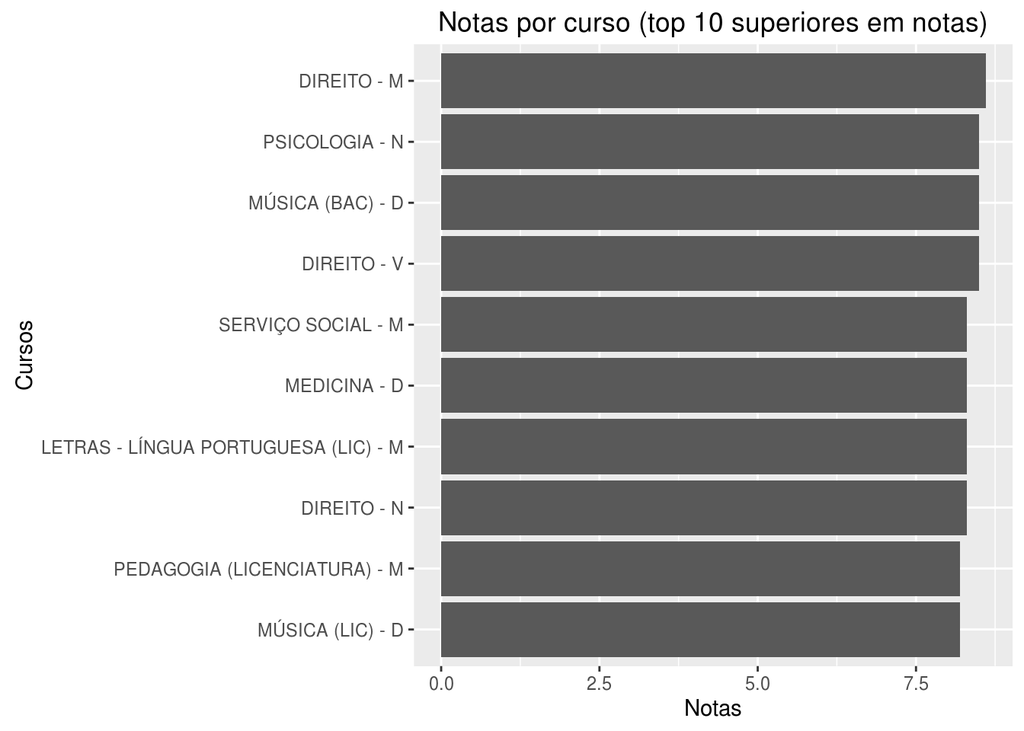

```r
#Notas por curso
notas_por_curso <- aggregate(dados$Media_Disciplina, list(dados$Nome_Curso), FUN = median, na.rm=TRUE)

notas_por_curso <- notas_por_curso[order(-notas_por_curso$x),]

ggplot(data=notas_por_curso[1:10,], aes(x=reorder(Group.1, x), y=x)) +
  geom_bar(stat="identity") +
  coord_flip() +
  labs(title="Notas por curso (top 10 superiores em notas)", x="Cursos", y="Notas")
```

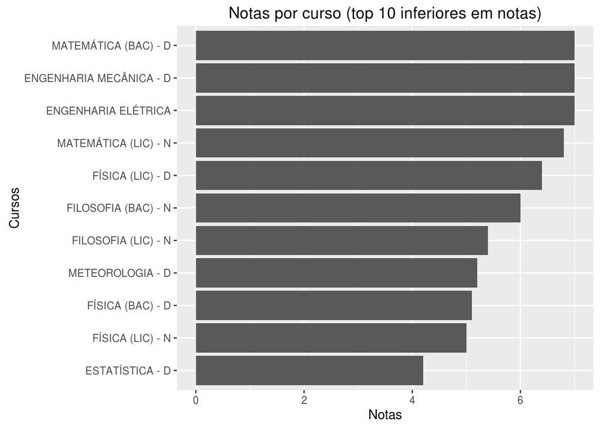

```r
ggplot(data=notas_por_curso[66:76,], aes(x=reorder(Group.1, x), y=x)) +
  geom_bar(stat="identity") +
  coord_flip() +
  labs(title="Notas por curso (top 10 inferiores em notas)", x="Cursos", y="Notas")
```

#### 2ª Pergunta

Em qual período estão as melhores e piores notas do curso de Ciência da Computação?

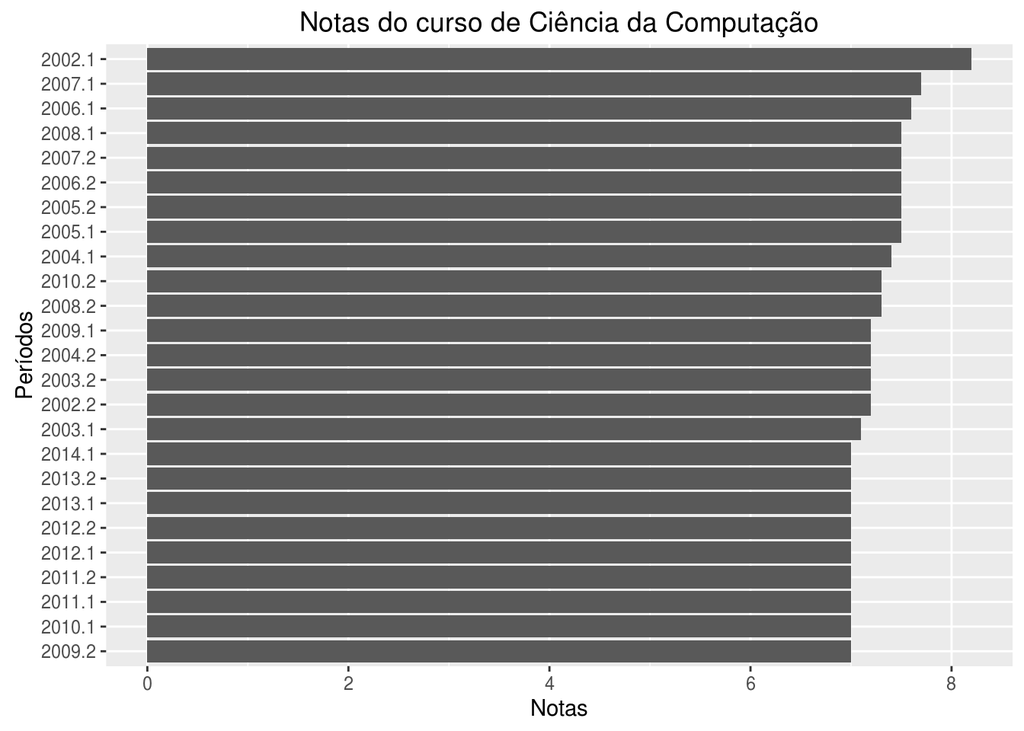

```r
#Notas Ciência da Computação

dados_cc <- dados %>%
  filter(Cod_Curso == 14102100)

notas_por_curso_cc <- aggregate(dados_cc$Media_Disciplina, list(dados_cc$Nome_Curso, dados_cc$Periodo), FUN = median, na.rm=TRUE)

ggplot(data=notas_por_curso_cc, aes(x=reorder(Group.2, x), y=x)) +
  geom_bar(stat="identity") +
  coord_flip() +
  labs(title="Notas do curso de Ciência da Computação", x="Períodos", y="Notas")
```

Agora reduzimos nosso escopo para olharmos apenas as notas do curso de Ciência da Computação, para isso agrupamos os períodos e utilizamos a mesma estratégia usada anteriormente, quando visualizamos as notas por curso, a mediana, visto que os períodos tem quantidades diferentes de alunos. Logo, o período com as melhores notas é 2002.1, porém como já foi falado, não devemos deixar de levar em conta a quantidade de alunos por cada período, nesse caso em 2002.1 a quantidade de alunos é a menor de todos os períodos.

#### 3ª Pergunta

Existe correlação entre as notas de Matemática Discreta e Cáclulo I para o curso de Ciência da Computação? Se sim, a correlação é positiva ou negativa? Qual a força dessa correlação? (Dica: cada par ordenada de notas (x,y) onde x é a nota de Cálculo I e y de Matemática Discreta corresponde a um aluno que cursou as duas disciplinas).

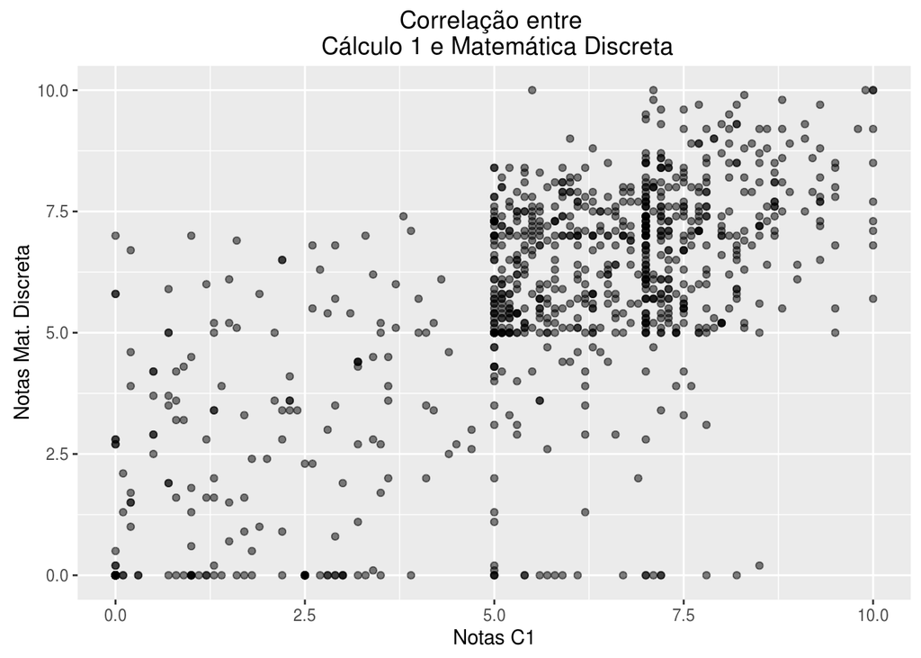

```r
#Correlação entre notas de cálculo 1 e matemática discreta

#selecionando notas de C1, agrupando por disciplina e pegando a primeira maior nota, caso o aluno tenha cursado mais de uma vez
notas_calculo1 <- dados_cc %>%
  filter(Nome_Disciplina == "CALCULO DIFERENCIAL E INTEGRAL I") %>%
  select(Matricula, Nome_Disciplina, Media_Disciplina) %>%
  group_by(Matricula) %>%
  top_n(1, Media_Disciplina)

#selecionando notas de matemática discreta, agrupando por disciplina e pegando a primeira maior nota, caso o aluno tenha cursado mais de uma vez
notas_mat_discreta <- dados_cc %>%
  filter(Nome_Disciplina == "MATEMÁTICA DISCRETA" ) %>%
  select(Matricula, Nome_Disciplina, Media_Disciplina) %>%
  group_by(Matricula) %>%
  top_n(1, Media_Disciplina)

#merde dos dois data frames anteriores
notas_C1_MD <- merge(notas_calculo1, notas_mat_discreta, by = "Matricula")

#removendo os NAs
notas_C1_MD <- na.omit(notas_C1_MD)

#plotando as notas
ggplot(notas_C1_MD, aes(x=Media_Disciplina.x, y=Media_Disciplina.y)) +
  geom_point(alpha = 0.5) +
  labs(title="Correlação entre \n Cálculo 1 e Matemática Discreta", x="Notas C1", y="Notas Mat. Discreta")
```

```r
#calculando a correlação entre as notas das disciplinas
corr_notas_cc <- cor(notas_C1_MD$Media_Disciplina.x, notas_C1_MD$Media_Disciplina.y)
corr_notas_cc
```

```
## [1] 0.6927944
```

Vamos analisar nossas conclusões e iniciar nossa resposta. Primeiramente, vamos relembrar o que é correlação. O coeficiente de correlação indica a força e a direção do relacionamento linear entre duas variáveis aleatórias. Nesse caso estamos utlizando o coeficiente de correlação de Pearson, ele assume valores entre -1 e 1. O coeficiente igual a 1 temos uma correlação muito forte e positiva, igual a 0 significa que as duas variáveis não dependem linearmente uma da outra e igual a -1 uma correlação negativa perfeita entre as duas variáveis, isto é, se uma aumenta, a outra sempre diminui. Observando nossos resultados vemos que existe correlação entre as disciplinas de cálculo 1 e matemática discreta, essa correlação vale aproximadamente 0.7, o que significa que temos uma correlação moderada e positiva, maior que zero.